# <font color="red"> Lecture 7 – Linear Models</font>

## STAT/BIOF/GSAT 540: Statistical Methods for High Dimensional Biology

### Keegan Korthauer

### 2020/01/27 <br><br><font size="5"> Slides by: Gabriela Cohen Freue with contributions from Jenny Bryan and Keegan Korthauer </font>

# Recall from last class...

### - show how to compare means of different groups (2 or more) using a linear regression model

- dummy variables to model the levels of a qualitative explanatory variable

### - write a linear model using matrix notation

- understand which matrix is built by R

### - distinguish between single and multiple hypotheses

- `\(t\)`-tests vs `\(F\)`-tests

## **Quick review**: from `\(t\)`-test to linear regression

[figure not shown]

## <font color="blue"> **HOW??** </font>

### Changing the parametrization and using dummy variables

<big>
$$
Y \sim G; \ E[Y]= \mu_Y ; \ Z \sim G; \ E[Z]= \mu_Z
$$

**↓**

`$$Y_{ij}=\theta+\tau_2 \times x_{ij2} + \varepsilon_{ij}; \ i=1, \dots, n; \ j={1,2}$$`

**↓**

`$$\begin{array}{l}
E[Y_{i1}] &= \theta=\mu_1 \\
E[Y_{i2}] &= \theta + \tau_2=\mu_1\ + (\mu_2 - \mu_1) = \mu_2
\end{array}$$`

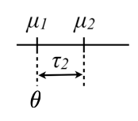

## **Using matrix notation ...**

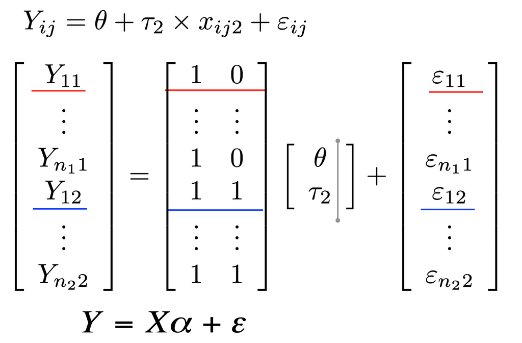

### ... and similarly beyond 2 groups comparisons (ANOVA)

[figure not shown]

##**Parametrizations**

### Different ways of writing this [design matrix, parameter vector] pair correspond to different parametrizations of the model

# `$$Y = [X\alpha] + \varepsilon$$`

<big>
 Understanding these concepts makes it easier ...
- to interpret fitted models
- to fit models such that comparisons you care most about are directly addressed in the inferential "report"

### For example: comparisons of mean expression levels between groups!

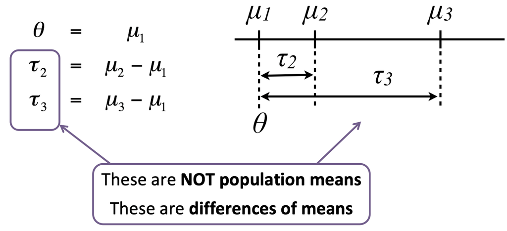

By default, `lm` estimates mean differences (with respect to a reference group):

```r
summary(lm(gExp~devStage,subset(devDat,gene=="theHit")))$coeff
```

```
##              Estimate Std. Error   t value     Pr(>|t|)
## (Intercept) 5.5408571  0.1021381 54.248698 1.307554e-34
## devStageP2  0.3040179  0.1398583  2.173756 3.678022e-02
## devStageP6  0.2433929  0.1398583  1.740282 9.085489e-02
## devStageP10 0.8342679  0.1398583  5.965093 9.559065e-07
## devStage4W  3.6325179  0.1398583 25.972843 5.266481e-24
```

## Today... more complex models

### - more than one factor with multiple levels

- how to model many categorical variables and their interaction

### - distinguish between simple and main effects

- `lm` vs `anova` tests

### - nested models

- `\(t\)`-tests vs `\(F\)`-tests

### - continuous explanatory variables

- the regression line

## Increasing the complexity of the linear model ...

### What if you have two categorical variables?

e.g., `gType` and `devStage` (for simplicity, let's consider only E16 and 4W)

- ANOVA is usually used to study models with one or more categorical variables (factors)

- Can we combine levels into 4 groups to simplify the analysis??

[figure not shown]

## Two-way ANOVA or a linear model with interaction

Which group means are we comparing in a model with 2 factors?

[figure not shown]

`$$\mu_1=E[Y_{(wt,E16)}], \ \mu_2=E[Y_{(NrlKO,E16)}],
\ \mu_3=E[Y_{(wt,4W)}], \ \mu_4=E[Y_{(NrlKO,4W)}]$$`

### Reference-treatment effect parametrization

By default, `lm` assumes a **reference-treatment effect** parametrization (mathematically, we need *more* dummy variables, see [math handout](../SupportingMaterial/math_handout.html))

```r
twoFactFit <- lm(gExp ~ gType * devStage, twoDat)
```

```
##                         Estimate Std. Error   t value     Pr(>|t|)
## (Intercept)            9.9080000  0.1574912 62.911469 2.027211e-15
## gTypeNrlKO            -0.9856667  0.2405717 -4.097184 1.767824e-03
## devStage4W             1.6345000  0.2227261  7.338609 1.469261e-05
## gTypeNrlKO:devStage4W -2.0380833  0.3278440 -6.216626 6.560671e-05
```

```r
means.2Fact <- as.data.frame(twoDat %>%
          group_by(grp) %>% summarize(cellMeans=mean(gExp)))
(means.2Fact <-means.2Fact %>%
          mutate(txEffects=cellMeans-cellMeans[1],
          lmEst=summary(twoFactFit)$coeff[,1]))
```

```
##         grp cellMeans  txEffects      lmEst
## 1    wt.E16  9.908000  0.0000000  9.9080000
## 2 NrlKO.E16  8.922333 -0.9856667 -0.9856667
## 3     wt.4W 11.542500  1.6345000  1.6345000
## 4  NrlKO.4W  8.518750 -1.3892500 -2.0380833
```

## The reference: <font color="blue"> wt & E16 </font>

<big>
As before, comparisons are relative to a reference but in this case there is a reference level in each factor: wt and E16

[figure not shown]

## The reference: wt & E16

<big>

**Mean of reference group**: `\(\theta=E[Y_{wt,E16}]\)`

**`lm` estimate**: `\(\hat{\theta}\)` is the sample mean of the group

```
##                         Estimate Std. Error   t value     Pr(>|t|)
## (Intercept)            9.9080000  0.1574912 62.911469 2.027211e-15
## gTypeNrlKO            -0.9856667  0.2405717 -4.097184 1.767824e-03
## devStage4W             1.6345000  0.2227261  7.338609 1.469261e-05
## gTypeNrlKO:devStage4W -2.0380833  0.3278440 -6.216626 6.560671e-05
```

```
##         grp cellMeans  txEffects      lmEst
## 1    wt.E16  9.908000  0.0000000  9.9080000
## 2 NrlKO.E16  8.922333 -0.9856667 -0.9856667
## 3     wt.4W 11.542500  1.6345000  1.6345000
## 4  NrlKO.4W  8.518750 -1.3892500 -2.0380833
```

In general, one is not interested in: `\(H_0: \theta=0\)`

## Simple genotype effect: wt *vs* NrlKO <font color="blue"> at E16 </font>

<big>
And now the "treatment effects"...

> **Important**: effects are not marginal but *conditional* effects (at a given level  of the other factor, e.g., at E16), usually called **simple effects**

[figure not shown]

## Simple genotype effect: wt *vs* NrlKO <font color="blue"> at E16 </font>

**Effect of genotype at E16**: `\(\tau_{KO}=E[Y_{NrlKO,E16}]-E[Y_{wt,E16}]\)`

**`lm` estimate**: `\(\hat{\tau}_{KO}\)` is the *difference* of sample respective means (check below)

```
##                         Estimate Std. Error   t value     Pr(>|t|)
## (Intercept)            9.9080000  0.1574912 62.911469 2.027211e-15
## gTypeNrlKO            -0.9856667  0.2405717 -4.097184 1.767824e-03
## devStage4W             1.6345000  0.2227261  7.338609 1.469261e-05
## gTypeNrlKO:devStage4W -2.0380833  0.3278440 -6.216626 6.560671e-05
```

```
##         grp cellMeans  txEffects      lmEst
## 1    wt.E16  9.908000  0.0000000  9.9080000
## 2 NrlKO.E16  8.922333 -0.9856667 -0.9856667
## 3     wt.4W 11.542500  1.6345000  1.6345000
## 4  NrlKO.4W  8.518750 -1.3892500 -2.0380833
```

**But**, do you want to test the *conditional* effect at E16: `\(H_0: \tau_{KO}=0\)`??

### Simple developmental effect: E16 *vs* 4W <font color="blue"> at wt </font>

<big>

Similarly, for the other factor:

[figure not shown]

### Simple developmental effect: E16 *vs* 4W <font color="blue"> at wt </font>

**Effect of development at wt**: `\(\tau_{4W}=E[Y_{wt,4W}]-E[Y_{wt,E16}]\)`

**`lm` estimate**: `\(\hat{\tau}_{4W}\)` is the *difference* of respective sample means (check below)

```
##                         Estimate Std. Error   t value     Pr(>|t|)
## (Intercept)            9.9080000  0.1574912 62.911469 2.027211e-15
## gTypeNrlKO            -0.9856667  0.2405717 -4.097184 1.767824e-03
## devStage4W             1.6345000  0.2227261  7.338609 1.469261e-05
## gTypeNrlKO:devStage4W -2.0380833  0.3278440 -6.216626 6.560671e-05
```

```
##         grp cellMeans  txEffects      lmEst
## 1    wt.E16  9.908000  0.0000000  9.9080000
## 2 NrlKO.E16  8.922333 -0.9856667 -0.9856667
## 3     wt.4W 11.542500  1.6345000  1.6345000
## 4  NrlKO.4W  8.518750 -1.3892500 -2.0380833
```

## Interaction effect

<big>

Is the effect of genotype the same at different developmental stages? (or does hte effect of development depend on genotype?)

**Yes if**, there's no interaction effect, i.e., `\(\tau_{KO4W}=0\)`

[figure not shown]

The genotype effect at E16 is `\(\tau_{KO}\)`. However, `\(\tau_{KO}\)` does not seem to be the effect at 4W. The difference is the interaction effect!